# Analysing companies 10-Ks for changes to predict stock price movement

## Top 20 used words in the 10K report

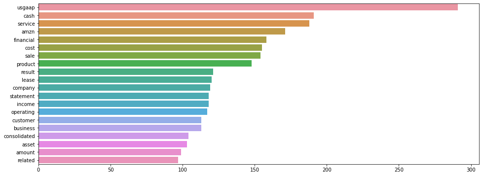

```python
counter=Counter(docs[list(docs.keys())[0]]) #first documents tokens from docs(which contains many tokens from different docs)
most=counter.most_common()

x, y=[], []
for word,count in most[:20]:
    x.append(word)
    y.append(count)

plt.figure(figsize=(16,6))
sns.barplot(x=y,y=x)
```

## Positivity Score of the 10K document

Finding the sentiment value of the document using the Texblob library.

```python
positivity = TextBlob(" ".join(docs[list(docs.keys())[0]])) #first documents tokens from docs(which contains many tokens from different docs)

print(positivity.sentiment)
```

```
Sentiment(polarity=0.07811700059963189, subjectivity=0.36037901272269396)
```

The polarity value ranges from [-1,1]. -1 meaning that the given string has a very negative context and whereas 1 has a very postive intent. 0 means that the statment is neutral, hence its neither positive or negative. For the document that we used, the score is about .08, refering that the document is more or less neutral or slightly positive. Again this doesnt help too much with our quantitative analysis.

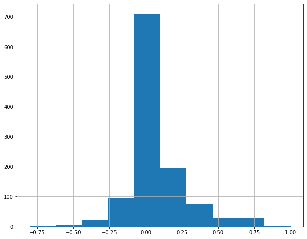

```python
def polarity(text):
    return TextBlob(" ".join(text)).sentiment.polarity


sentences = pd.DataFrame(columns=["sentences","polarity_score"])

for sent in dataset:
    sentences = sentences.append({'sentences':sent, 'polarity_score':polarity(sent) }, ignore_index=True)


sentences['polarity_score'].hist(figsize=(10,8))
```

The above graph shows us the distribution of polarity over the sentences. As we can see here that most of the words used in the 10-K document are very neutral and use their words very consciously.

```python
# Displaying the sentences that had a polarity score of over .5

sentences[sentences['polarity_score']>.5]
```

|  | sentences | polarity_score |
| --- | --- | --- |
| 6 | [indicate, check, mark, disclosure, delinquent... | 1.000 |
| 44 | [also, believe, platform, flexibility, allows,... | 0.800 |
| 130 | [none, employee, represented, labor, union, co... | 0.700 |
| 181 | [effect, acquisition, business, combination, a... | 0.750 |
| 194 | [addition, benefit, newer, market, segment, fi... | 0.525 |
| 245 | [determine, decline, fair, value, investment, ... | 0.700 |
| 264 | [order, successful, must, accurately, predict,... | 0.575 |
| 358 | [cost, incur, result, liability, relating, sal... | 0.700 |
| 359 | [running, amazon, marketplace, auction, zshops... | 0.550 |
| 362 | [guarantee, program, fraudulent, activity, use... | 0.700 |
| 561 | [nonamortization, approach, goodwill, would, a... | 0.700 |
| 564 | [record, impairment, loss, goodwill, intangibl... | 0.700 |
| 639 | [also, recorded, unearned, revenue, equity, se... | 0.700 |
| 645 | [valuation, also, reduce, otherwise, fair, val... | 0.600 |
| 647 | [fair, value, security, le, amount, cash, paid... | 0.700 |
| 650 | [accounting, grantee, equity, instrument, rece... | 0.700 |
| 658 | [also, made, cash, payment, investment, equity... | 0.550 |
| 663 | [unrealized, gain, represent, difference, comp... | 0.700 |
| 667 | [fair, value, equity, security, classified, ma... | 0.700 |
| 738 | [asset, company, acquired, recorded, fair, val... | 0.700 |
| 756 | [investment, included, marketable, security, a... | 0.700 |
| 760 | [case, company, estimated, fair, value, equity... | 0.700 |
| 765 | [valuation, also, reduce, fair, value, account... | 0.600 |
| 768 | [company, periodically, evaluates, whether, de... | 0.700 |
| 782 | [goodwill, intangible, goodwill, represents, e... | 0.700 |
| 785 | [company, record, impairment, loss, goodwill, ... | 0.700 |
| 791 | [measurement, fair, value, businessunit, goodw... | 0.700 |
| 796 | [longlived, asset, disposed, carried, fair, va... | 0.700 |
| 814 | [valuation, also, reduce, fair, value, account... | 0.600 |
| 835 | [company, provides, additional, forma, disclos... | 0.700 |
| 856 | [requires, derivative, instrument, recorded, b... | 0.700 |
| 892 | [impairment, loss, recorded, reflect, investme... | 0.700 |
| 910 | [unrealized, gain, represent, difference, comp... | 0.700 |
| 917 | [fair, value, equity, security, classified, ma... | 0.700 |
| 944 | [fair, value, forward, purchase, agreement] | 0.700 |
| 945 | [based, upon, quoted, market, price, fair, val... | 0.700 |
| 1104 | [nonqualified, stock, option, letter, agreemen... | 0.600 |
| 1106 | [nonqualified, stock, option, letter, agreemen... | 0.600 |
| 1143 | [nonqualified, stock, option, letter, agreemen... | 0.600 |
| 1145 | [nonqualified, stock, option, letter, agreemen... | 0.600 |

## Calculating the Similarity Score

For this part, I will use [cosine similarity](http://scikit-learn.org/stable/modules/metrics.html#cosine-similarity) and [Jaccard similarity](http://scikit-learn.org/stable/modules/model_evaluation.html#jaccard-similarity-score) to compare the various 10K documents over the years from a particular company and find their similarity over years.

```python
def CosSimilarity(A, B):

    '''
    The input paramters A and B are words from two different documents
    '''
    # Compile complete set of words in A or B
    words = list(A.union(B))

    # Determine which words are in A
    vec_A = [1 if x in A else 0 for x in words]

    # Determine which words are in B
    vec_B = [1 if x in B else 0 for x in words]

    # Compute cosine score using scikit-learn
    array_A = np.array(vec_A).reshape(1, -1)
    array_B = np.array(vec_B).reshape(1, -1)

    cosine_score = cosine_similarity(array_A, array_B)[0,0]

    return cosine_score
```

```python
def JaccardSimilarity(A, B):

    '''
    The input paramters A and B are words from two different documents
    and this function return the JaccardSimilarityScore
    '''

    # Count number of words in both A and B
    intersect = len(A.intersection(B))

    # Count number of words in A or B
    union = len(A.union(B))

    # Compute Jaccard similarity score
    jaccard_score = intersect / union

    return jaccard_score
```

```python
def ComputeSimilarityScores10K(cik):


    # Open the directory that holds text filings for the CIK
    os.chdir(cik+'/textonly')
    print("Parsing CIK %s..." % cik)

    # Get list of files to over which to compute scores
    # excluding hidden files and directories
    flist = [fname for fname in os.listdir()]
    flist.sort()

    # Check if scores have already been calculated...
    try:
        os.mkdir('../metrics')
    # ... if they have been, exit
    except OSError:
        print("Similarity Scores are already calculated")
        os.chdir('../..')
        return

    # Check if enough files exist to compute sim scores...
    # If not, exit

    if not len(flist):
        return

    if len(flist) < 2:
        print("No files to compare for CIK", cik)
        os.chdir('../..')
        return

    # Initialize dataframe to store sim scores
    #find the dates from the names of the files that are present in the "textonly directory"
    dates = [x[-14:-4] for x in flist]

    #creating an empty array according to match the size of the cosine score

    cosscore = [0]*len(dates)
    jaccard_score = [0]*len(dates)

    data = pd.DataFrame(columns={'cosine_score': cosscore,
                                 'jaccard_score': jaccard_score},
                       index=dates)

    # Open first file
    file_A = flist[0]

    with open(file_A, 'r') as file:

        text_A = file.read()

    # Iterate over each 10-K file...
    for i in range(1, len(flist)):

        file_B = flist[i]

        # Get file text B
        with open(file_B, 'r') as file:
            text_B = file.read()

        # Get set of words in A, B
        words_A = set(re.findall(r"[\w']+", text_A))

        words_B = set(re.findall(r"[\w']+", text_B))

        # Calculate similarity scores
        cos_score = CosSimilarity(words_A, words_B)
        jaccard_score = JaccardSimilarity(words_A, words_B)

        # Store score values
        date_B = file_B[-14:-4]
        data.at[date_B, 'cosine_score'] = cos_score
        data.at[date_B, 'jaccard_score'] = jaccard_score

        # Reset value for next loop
        # (We don't open the file again, for efficiency)
        text_A = text_B

    # Save scores
    os.chdir('../metrics')
    data.to_csv(cik+'_sim_scores.csv', index=True)
    os.chdir('../..')
    print("Metics Successfully Calulated, Check Metrics Directory")
```

```python
# Calculating the similarity score for the nearest 10-K files in the "metrics" directory

os.chdir(path_10k)

for cik in tqdm(tick_cik_df['cik']):
    ComputeSimilarityScores10K(cik)
```

```
Parsing CIK 0001018724...
```

```
Metics Successfully Calulated, Check Metrics Directory
```

### Constructing the similarity index dataframe

```python
cik = tick_cik_df['cik'][0]

sim_df = pd.read_csv(path_10k+"/"+cik+"/metrics/"+cik+"_sim_scores.csv")

new_columns = sim_df.columns.values
new_columns[0] = 'Dates'
sim_df.columns = new_columns
sim_df = sim_df.set_index('Dates')

sim_df = sim_df.fillna(0)

sim_df['cosine_score'] = sim_df['cosine_score'].astype(float)

sim_df['jaccard_score'] = sim_df['jaccard_score'].astype(float)

sim_df = pd.concat( [sim_df, sim_df.pct_change()] , axis = 1, sort=False)
sim_df
```

| Dates | cosine_score | jaccard_score | cosine_score | jaccard_score |
| --- | --- | --- | --- | --- |
| 2001-03-23 | 0.000000 | 0.000000 | NaN | NaN |
| 2002-01-24 | 0.862940 | 0.758853 | inf | inf |
| 2003-02-19 | 0.864848 | 0.761874 | 0.002211 | 0.003981 |
| 2004-02-25 | 0.851950 | 0.741768 | -0.014913 | -0.026391 |
| 2005-03-11 | 0.861708 | 0.756727 | 0.011453 | 0.020167 |
| 2006-02-17 | 0.892635 | 0.806089 | 0.035891 | 0.065230 |
| 2007-02-16 | 0.894098 | 0.808454 | 0.001638 | 0.002934 |
| 2008-02-11 | 0.925033 | 0.860487 | 0.034600 | 0.064361 |
| 2009-01-30 | 0.912895 | 0.839693 | -0.013122 | -0.024165 |
| 2010-01-29 | 0.910969 | 0.836496 | -0.002109 | -0.003808 |
| 2011-01-28 | 0.911847 | 0.837964 | 0.000963 | 0.001755 |
| 2012-02-01 | 0.898984 | 0.815545 | -0.014106 | -0.026755 |
| 2013-01-30 | 0.897201 | 0.813449 | -0.001984 | -0.002570 |
| 2014-01-31 | 0.829994 | 0.709302 | -0.074907 | -0.128031 |
| 2015-01-30 | 0.903684 | 0.824288 | 0.088784 | 0.162111 |
| 2016-01-29 | 0.900408 | 0.818542 | -0.003625 | -0.006971 |
| 2017-02-10 | 0.911172 | 0.836827 | 0.011954 | 0.022338 |
| 2018-02-02 | 0.902087 | 0.821606 | -0.009971 | -0.018189 |
| 2019-02-01 | 0.909733 | 0.834296 | 0.008476 | 0.015445 |
| 2020-01-31 | 0.886158 | 0.794998 | -0.025914 | -0.047103 |

In the above dataframe, we can observe that over the years the cosine similarity score and the jaccard score are very close and barely any difference.

## Comparing our hypothesis with the real stock market situation

```python
tickers = [tick_cik_df['ticker'][0]]

time_series =web.DataReader(tickers, "av-monthly-adjusted", start=datetime(2001, 3, 23),end=datetime(2020, 10, 31),api_key='UGBIPKZSN5NWM5LV')
time_series
```

|  | open | high | low | close | adjusted close | volume | dividend amount |
| --- | --- | --- | --- | --- | --- | --- | --- |
| 2001-03-30 | 9.875 | 14.00 | 9.563 | 10.23 | 10.23 | 167635900 | 0.0 |
| 2001-04-30 | 10.330 | 18.16 | 8.100 | 15.78 | 15.78 | 189780400 | 0.0 |
| 2001-05-31 | 15.900 | 17.60 | 13.100 | 16.69 | 16.69 | 144686700 | 0.0 |
| 2001-06-29 | 17.220 | 17.92 | 11.200 | 14.15 | 14.15 | 136695900 | 0.0 |
| 2001-07-31 | 14.100 | 17.42 | 11.070 | 12.49 | 12.49 | 172078700 | 0.0 |
| ... | ... | ... | ... | ... | ... | ... | ... |
| 2020-06-30 | 2448.000 | 2796.00 | 2437.130 | 2758.82 | 2758.82 | 87845661 | 0.0 |
| 2020-07-31 | 2757.990 | 3344.29 | 2754.000 | 3164.68 | 3164.68 | 127304238 | 0.0 |
| 2020-08-31 | 3180.510 | 3495.00 | 3073.000 | 3450.96 | 3450.96 | 83519879 | 0.0 |
| 2020-09-30 | 3489.580 | 3552.25 | 2871.000 | 3148.73 | 3148.73 | 115969967 | 0.0 |
| 2020-10-30 | 3208.000 | 3496.24 | 3019.000 | 3036.15 | 3036.15 | 116252115 | 0.0 |

236 rows × 7 columns

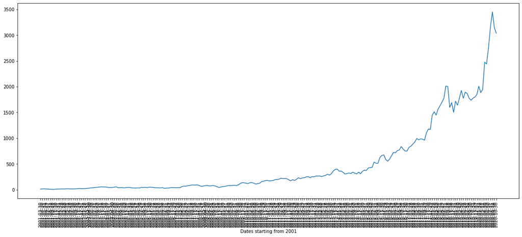

```python
x = time_series.index.values.tolist()
y = time_series['adjusted close']

# dates = [datetime.strptime(date,"%Y-%m-%d")for date in x ]
# i = 2001
# years = [i for i in range(2021)]
# plt.xticks(x,x[::12],rotation='vertical')
# plt.locator_params(axis='x', nbins=len(x)/11)

plt.figure(figsize=(20,8))
plt.xticks(rotation=90)
plt.xlabel("Dates starting from 2001")
plt.plot(x,y)
plt.show()
```

# Conclusion

However we can stop here. It is important to test the hypothesis with other stocks before we come to any concrete conclusion.